# Documentazione

Andrea & Ottavia

2022-10-28

# 1 Classe campo

La classe `field` contiene le informazioni neccessarie per plottare il contenuto di una cella della matrice.

```r
field <- list(
  shape = NULL,
  size.x = NULL,
  size.y = NULL,
  rotation = NULL,
  pos.x = NULL,
  pos.y = NULL,
  lty = NULL,
  lwd = NULL,
  num = NULL,
  nv=NULL,
  shade=NULL,
  visible= NULL
  )
```

- `shape` è un vettore contente stringhe di caratteri, ogni elemento della stringa indica la forma che si vuole sviluppare, per esempio `c('circle','square')`
- `size.x` e `size.y` un vettore o un scalare che danno informazione per il semi-asse maggiore e minore del elisse entro il quale è inscritto il poligono (corrispondono a `radius.x` e `radius.y` del pacchetto `DescTools`)

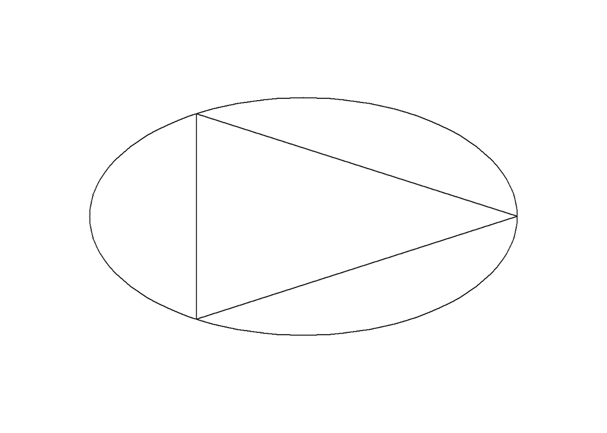

```r
library(DescTools)
Canvas(c(-5,5),c(-5,5)) # non è necessario il secondo c(-5,5) basta Canvas(c(-5,5))
DrawRegPolygon(x = 0, y = 0, radius.x=9,radius.y = 5, nv = 100)
DrawRegPolygon(x = 0, y = 0, radius.x=9,radius.y = 5, nv = 3)
```

# 2 Classe matrice

La classe `Raven_matrix` contiene tutte le informazioni neccessarie per classificare la creazione della matrice.

```r
Raven<-list(
    Sq1 = list(),
    Sq2 = list(),
    Sq3 = list(),

    Sq4 = list(),
    Sq5 = list(),
    Sq6 = list(),

    Sq7 = list(),
    Sq8 = list(),
    Sq9 = list(),
    hrule = list(),
    vrule = list()
  )
```

I campi da `Sq1` a `Sq9` corrispondono alle celle della matrice.

```
##      [,1]  [,2]  [,3]
## [1,] "Sq1" "Sq2" "Sq3"
## [2,] "Sq4" "Sq5" "Sq6"
## [3,] "Sq7" "Sq8" "Sq9"
```

Ogni cella della matrice andrà a contenere un oggetto di classe `field` contenente tutte le possibili forme al suo interno.

I campi `hrule` e `vrule` sono due vettori contententi le regole.

- `hrule` contiene le regole che verranno applicate secondo la logica orizzontale. L’ordine delle regole nel vettore corrisponde al ordine di applicazione.
- `vrule` contiene le regole che verranno applicate secondo la logica verticale. L’ordine delle regole nel vettore corrisponde al ordine di applicazione.

Logiche più complesse vengono ottenute tramite composizioni di orizzontale e verticale.

# 3 Forme di Default

## 3.1 Cerchio

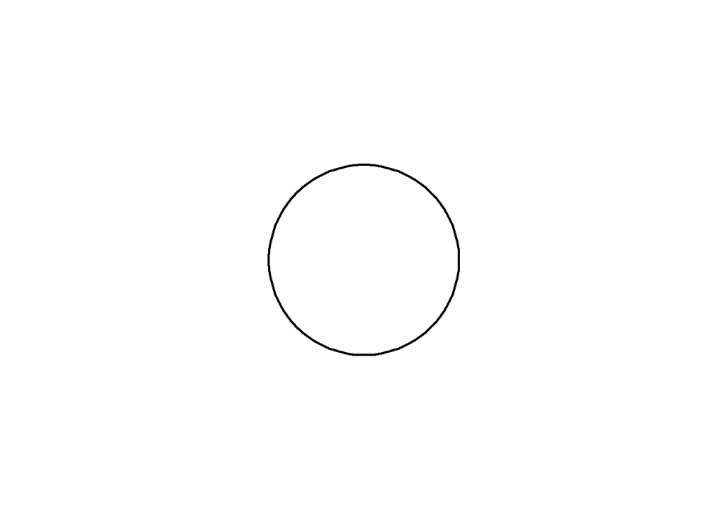

```r
Canvas(15,15)

DrawRegPolygon(x = circle()$pos.x, y = circle()$pos.y, radius.x=circle()$size.x,
               radius.y = circle()$size.y, rot=circle()$rotation,
               lwd = circle()$lwd, lty=circle()$lty, nv = circle()$nv)
```

## 3.2 Triangolo

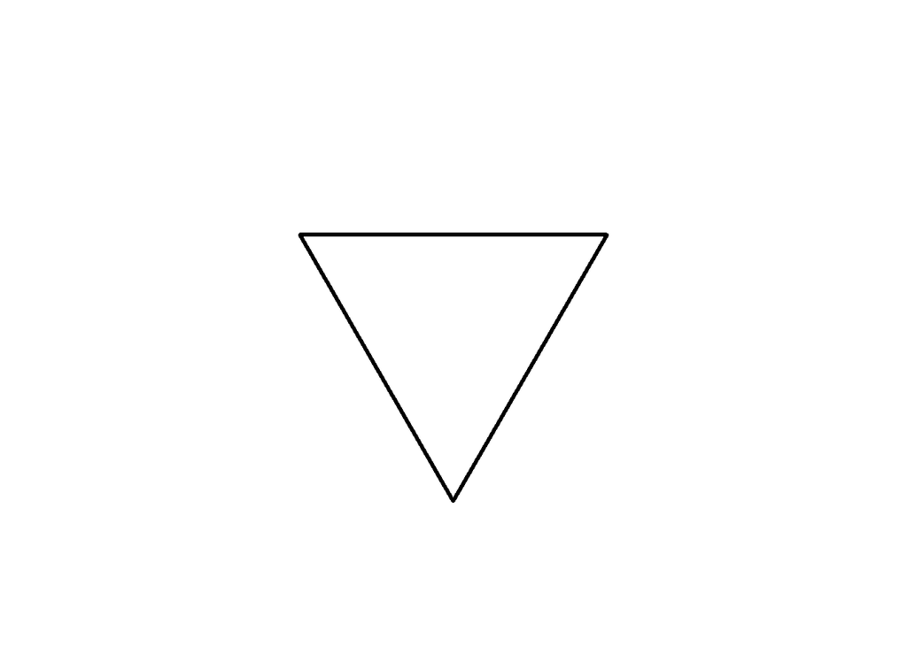

```r
Canvas(15, 15)
DrawRegPolygon(radius.x = triangle()$size.x,
               radius.y = triangle()$size.y,
               lwd = triangle()$lwd,
               lty = triangle()$lty, nv = triangle()$nv, rot = triangle()$rotation)
```

## 3.3 Quadrato

## 3.4 Linea verticale

## 3.5 Linea orizzontale

## 3.6 Croce

## 3.7 Dado

## 3.8 Dot

## 3.9 Elisse

## 3.10 Piccolo triangolo (circa)

# 4 Concatenazione di Forme

La funzione field puo venire utilizzata per generare una qualsiasi forma, gli input della funzione sono esattamente le caratteristiche della classe campo.

```r
source("Basic_function_20102022.R")
campo_generico<-field("simbolo_di_batman",15,5,pi,0,0,1,2,1,15,1,0)
campo_generico
```

```
## $shape
## [1] "simbolo_di_batman"
##
## $size.x
## [1] 15
##
## $size.y
## [1] 5
##
## $rotation
## [1] 3.141593
##
## $pos.x
## [1] 0
##
## $pos.y
## [1] 0
##
## $lty
## [1] 1
##
## $lwd
## [1] 2
##
## $num
## [1] 1
##
## $nv
## [1] 15
##
## $shade
## [1] 1
##
## $visible
## [1] 0
##
## attr(,"class")
## [1] "field"
```

La funzione `cof` concatena diversi campi esattamente secondo la stessa logica di `c()`

```r
cof(campo_generico,circle(),triangle()) # ho corretto il codice di circle perché altrimenti diceva ellipse
```

```
## $shape
## [1] "simbolo_di_batman" "circle"            "triangle"
##
## $size.x
## [1] 15 10 15
##
## $size.y
## [1]  5 10 15
##
## $rotation
## [1] 3.1415927 0.0000000 0.5235988
##
## $pos.x
## [1] 0 0 0
##
## $pos.y
## [1] 0 0 0
##
## $lty
## [1] 1 1 1
##
## $lwd
## [1] 2 2 3
##
## $num
## [1] 1 1 1
##
## $nv
## [1]  15 100   3
##
## $shade
## [1] "1"    "none" "none"
##
## $visible
## [1] 0 1 1
##
## attr(,"class")
## [1] "field"
```

```r
# bisogna correggere tutto il codice (è ellipse non ellipse), lo faccio io
```

# 5 Creazione di una matrice

La funzione `Raven` crea una matrice di Raven in cui tutte le celle della matrice vengono inizializzate identiche alla cella `Sq1`, e vengono inizializzate le regole.

- `St1` classe field che contiene i campi di partenza per tutte le celle
- `hrule` vettore delle regole applicabili con logica orizzontale
- `vrule` vettore delle regole applicabili con logica verticale

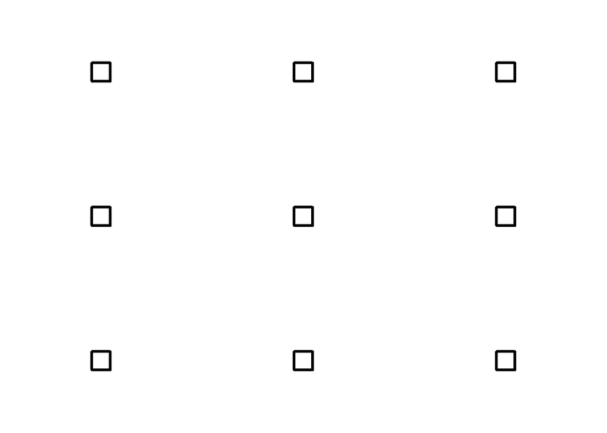

```r
M<-Raven(st1=square(),hrule=c("size"),vrule=c("identity"))
draw(M)
```

Nella matrice `M` le regole non sono ancora state applicate, infatti nel plot d’esempio i quadrati hanno tutti le stesse dimensioni.

L’estensione del metodo `apply` applica le regole presenti nella matrice a tutte le celle. Al momento applica le regole prima in riga e poi in colonna.

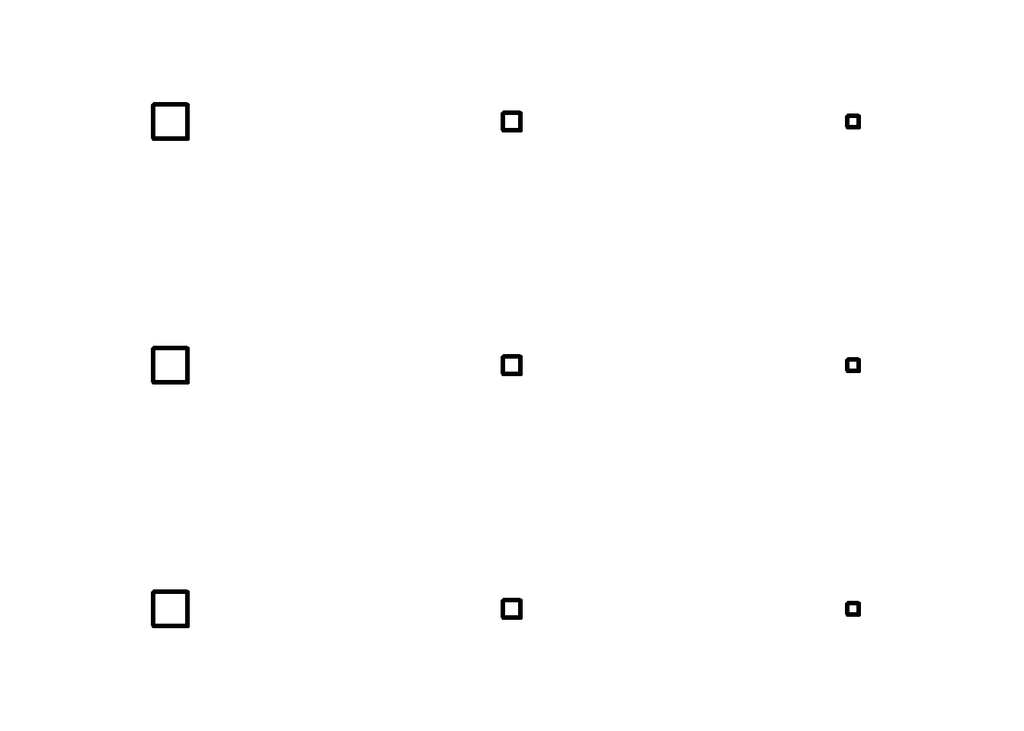

```r
M<-apply(M)
draw(M)
```

# 6 Regole

## 6.1 Rotazione

Il metodo rotazione cambia il valore `field$rotation` di rotazioni fisse con un angolo di $\frac{\pi}{4}$

- `obj` il contenuto di una cella della matrice
- `n` rappresenta l’ennesimo elemento a cui viene applicata la regola. Per esempio se la regola viene applicata orizzontalmente `n =1` per `Sq1`,`Sq4` e `Sq7`, `n =2` per `Sq2`,`Sq5` e `Sq8` e per finire `n =3` per `Sq3`,`Sq6` e `Sq9`.

```r
rotation.field<-function(obj,n,...) {
  obj$rotation<-obj$rotation+(n-1)*pi/4
  return(obj)
}
```

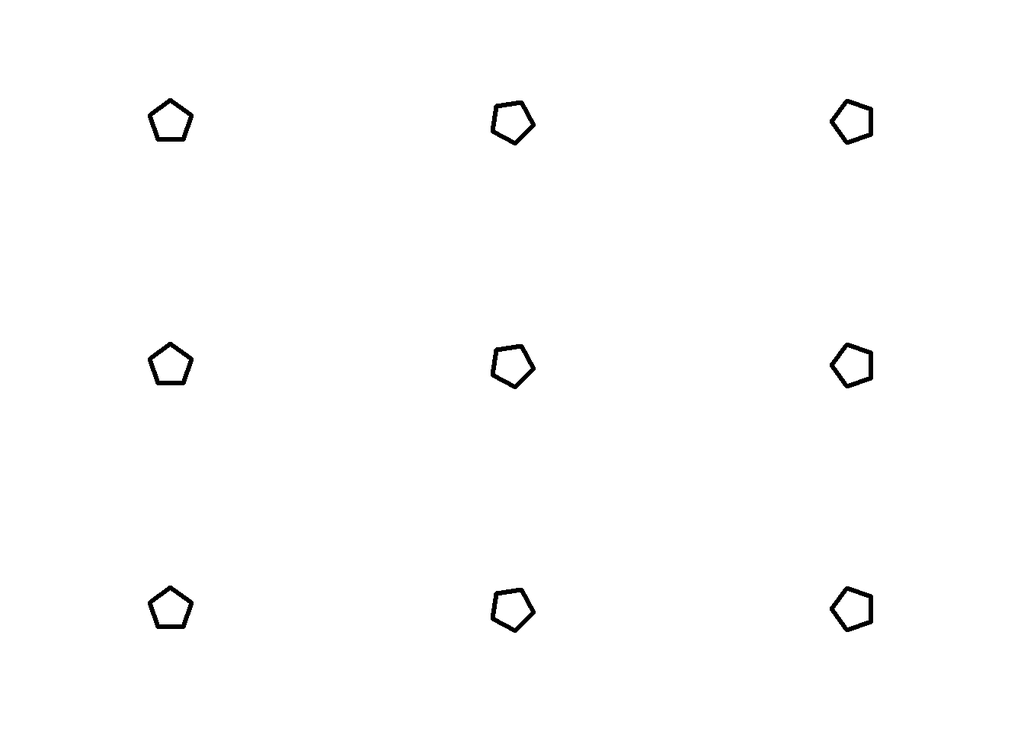

```r
#Horizontal
M<-apply(Raven(st1=pentagon(),hrule=c("rotation"),vrule=c("identity")))
draw(M)
```

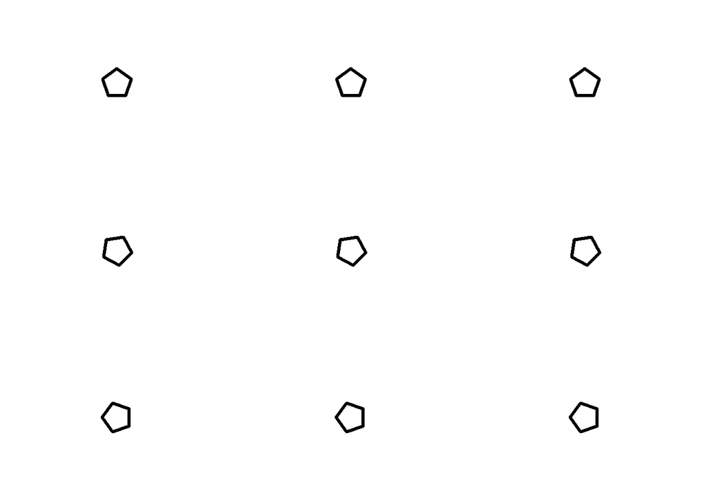

```r
#Vertical
M<-apply(Raven(st1=pentagon(),hrule=c("identity"),vrule=c("rotation")))
draw(M)
```

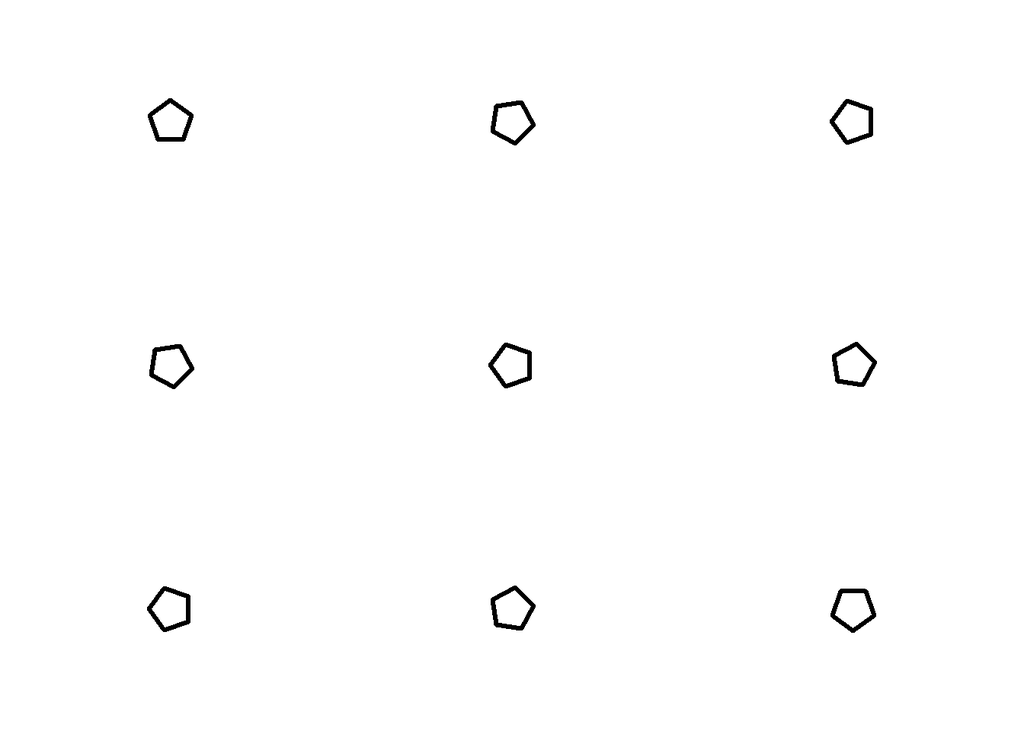

```r
# Top Left Low Right
M<-apply(Raven(st1=pentagon(),hrule=c("rotation"),vrule=c("rotation")))
draw(M)
```

## 6.2 Dimensione

Il metodo di cambio di dimensioni, riduce i valori di `field$size.x` e `field$size.y` di un valore costante pari a numero di riga (o colonna) della matrice per $k=.9$. Se per esempio la regola è applicata orizzontalmente, gli elementi nelle celle `Sq1,Sq4,sq7`della prima colonna hanno dimensioni $(\frac{x}{k},\frac{y}{k})$, gli elementi nelle celle `Sq2,Sq5,sq8` hanno dimensioni $(\frac{x}{2k},\frac{y}{2k})$ e quelli nella terza colonna $(\frac{x}{3k},\frac{y}{3k})$.

```r
size.field<-function(obj,n,...) {
  obj$size.x<-obj$size.x/(n*.9)
  obj$size.y<-obj$size.y/(n*.9)
  return(obj)
}
```

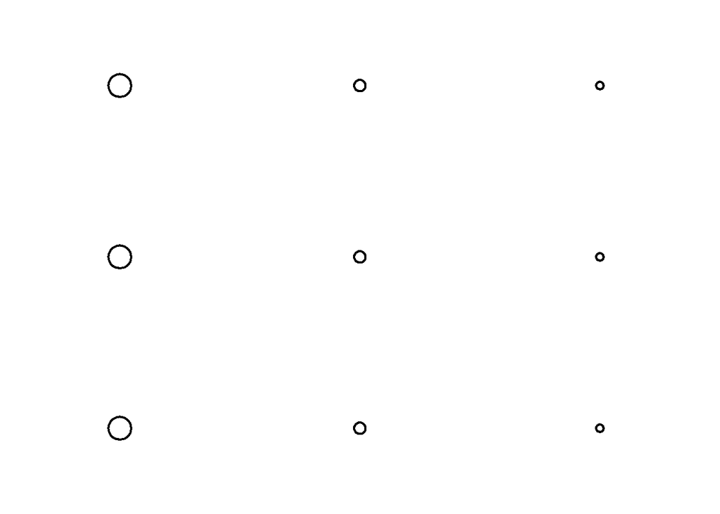

```r
#Horizontal
M<-apply(Raven(st1=circle(),hrule=c("size"),vrule=c("identity")))
draw(M)
```

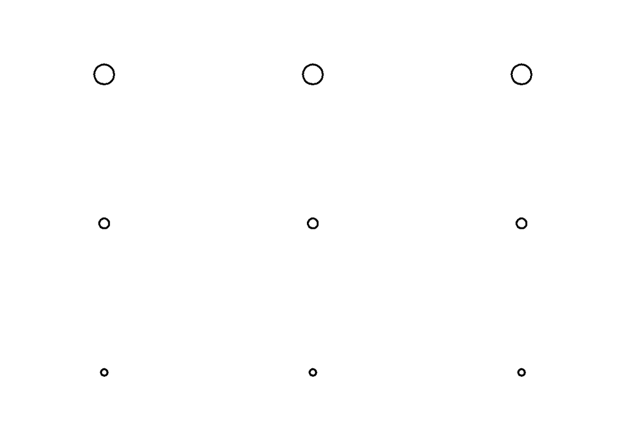

```r
#Vertical
M<-apply(Raven(st1=circle(),hrule=c("identity"),vrule=c("size")))
draw(M)
```

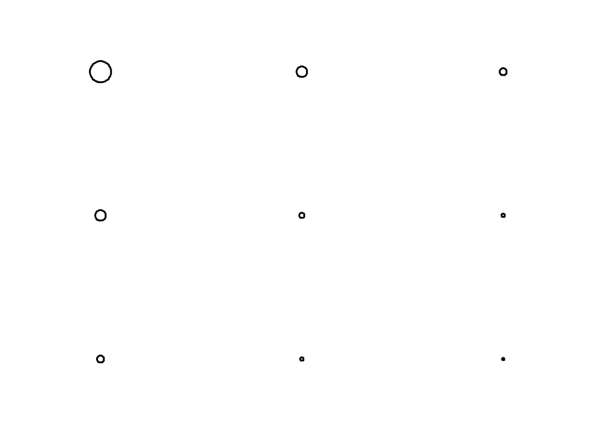

```r
# Top Left Low Right
M<-apply(Raven(st1=circle(),hrule=c("size"),vrule=c("size")))
draw(M)
```

## 6.3 Cambio delle forme

Il metodo di cambio di forma manipola il campo `field$visible` in modo di alternare tre diverse forme. L’ordine di applicazione va dalla terza alla prima forma. Per ogni cella individua quali forme sono visibili - Se più di una forma è visibile le rende tutte invisibili e seleziona solo quella in posizione $n$. Dove $n$ è l’indice di riga (o di colonna) - Se una sola forma è visibile la regola la mette invisibile e seleziona quella a distante $n$ nel vettore `index`

```r
diff_shapes.field<-function(obj,n,...) {
  if(length(obj$visible)!=3)
  {
    stop("You must have at least three forms to change shapes!")
  }
  index<-c(3:1,3:1,3:1)
  pos<-which(obj$visible==1)
  if(length(pos)>1){
    obj$visible[pos]<-0
    obj$visible[index[n]]<-1
  }else {
    obj$visible[pos]<-0
    obj$visible[index[pos+n]]<-1
  }

  return(obj)
}
```

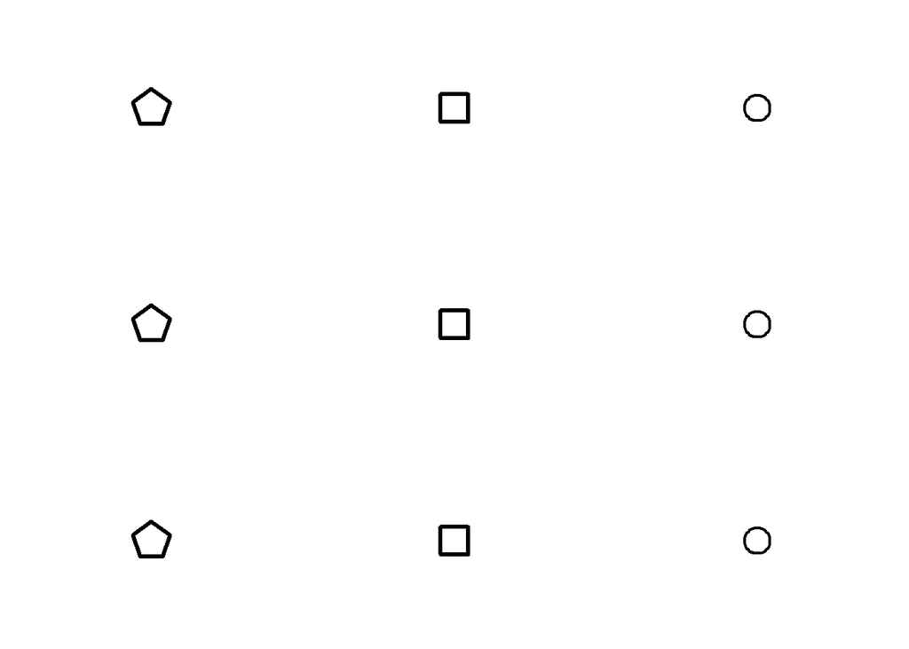

```r
#Horizontal
M<-apply(Raven(st1=cof(circle(),square(),pentagon()),hrule=c("diff_shapes"),vrule=c("identity")))
draw(M)
```

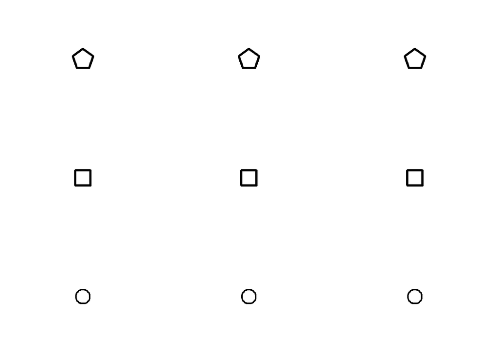

```r
#Vertical
M<-apply(Raven(st1=cof(circle(),square(),pentagon()),hrule=c("identity"),vrule=c("diff_shapes")))
draw(M)
```

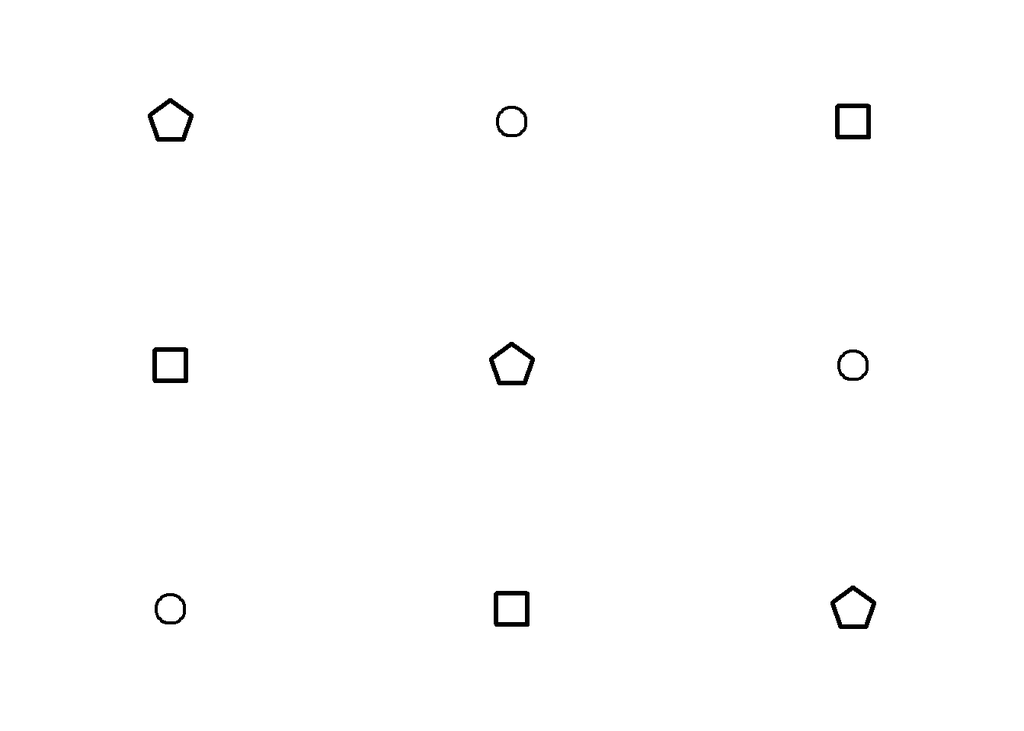

```r
# Top Left Low Right
M<-apply(Raven(st1=cof(circle(),square(),pentagon()),hrule=c("diff_shapes"),vrule=c("diff_shapes")))
draw(M)
```

## 6.4 Contorno

```r
margin.field<-function(obj,n,rules,...){
  index<-c(3:1,3:1,3:1)
  if(grepl("lwd",rules)){
    obj$lwd<- index[obj$lwd+n]+1
  }else if(grepl("lty",rules)){
    obj$lty<-index[obj$lty+n]
    }
  return(obj)
}
```

### 6.4.1 Spessore del contorno

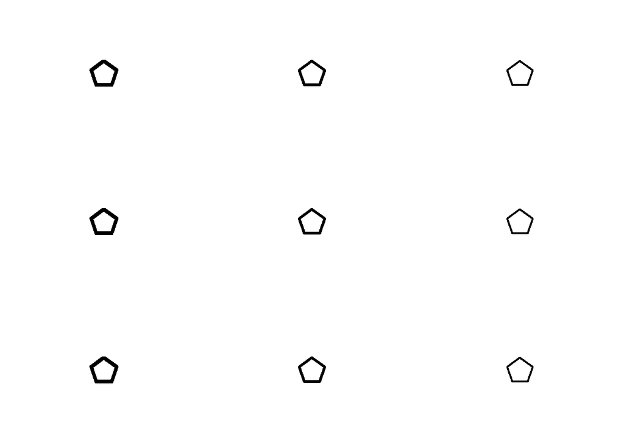

```r
#Horizontal
M<-apply(Raven(st1=pentagon(),hrule=c("lwd"),vrule=c("identity")))
draw(M)
```

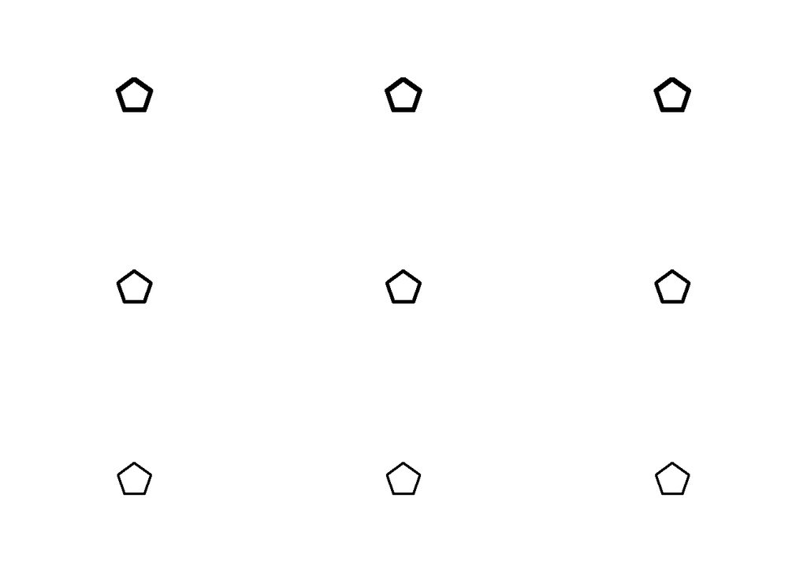

```r
#Vertical
M<-apply(Raven(st1=pentagon(),hrule=c("identity"),vrule=c("lwd")))
draw(M)
```

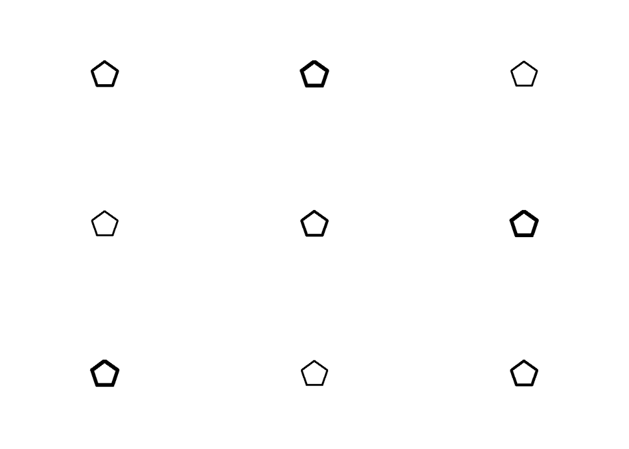

```r
# Top Left Low Right
M<-apply(Raven(st1=pentagon(),hrule=c("lwd"),vrule=c("lwd")))
draw(M)
```

### 6.4.2 Tipo del contorno

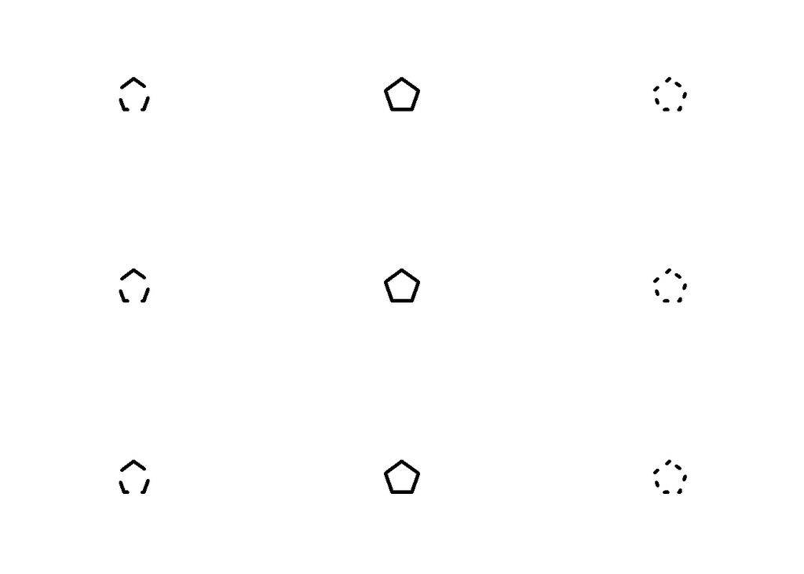

```r
#Horizontal
M<-apply(Raven(st1=pentagon(),hrule=c("lty"),vrule=c("identity")))
draw(M)
```

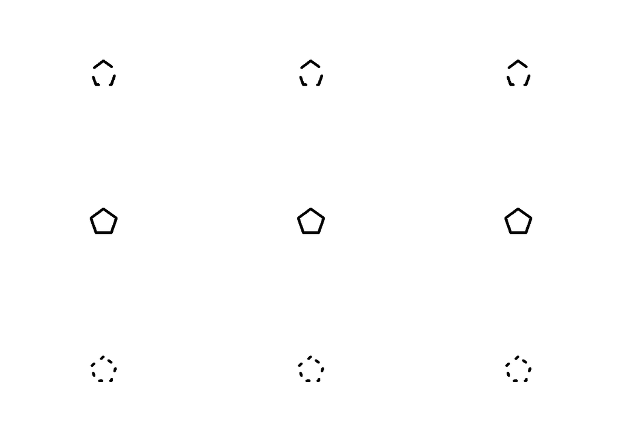

```r
#Vertical
M<-apply(Raven(st1=pentagon(),hrule=c("identity"),vrule=c("lty")))
draw(M)
```

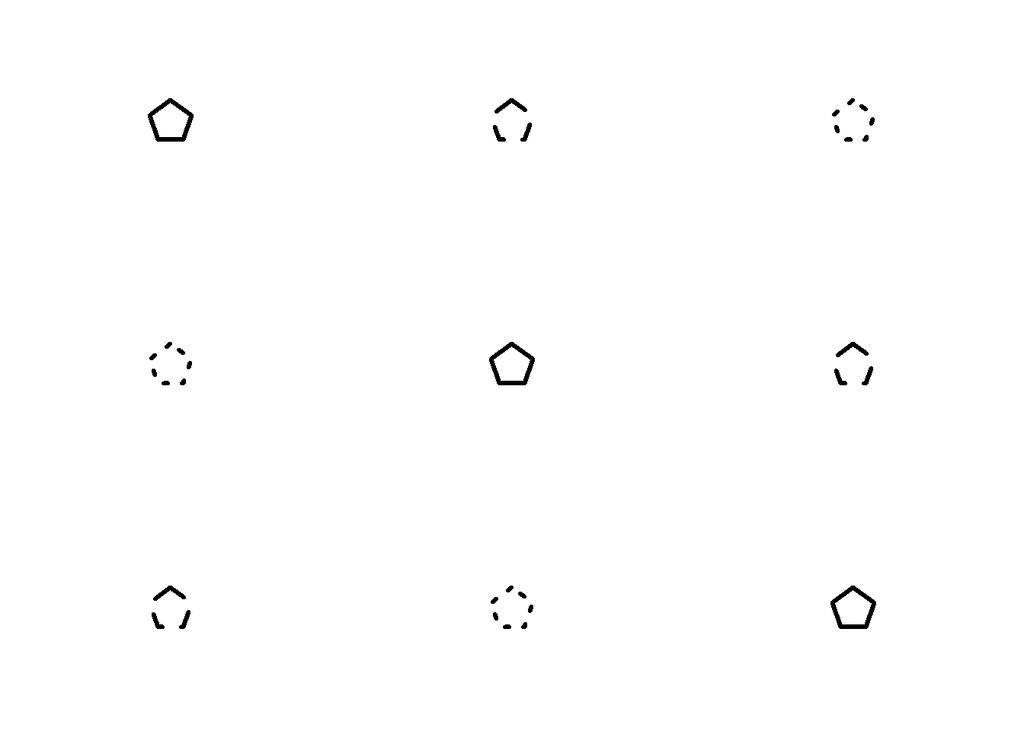

```r
# Top Left Low Right
M<-apply(Raven(st1=pentagon(),hrule=c("lty"),vrule=c("lty")))
draw(M)
```

### 6.4.3 Riempimento monocromatico

La regola per il rimepimento monocromatico cambia il campo `field$shade` tra i valori `white`, `black` e `grey`. I tre diversi riempimenti vengono assegnati tramite l’indice di riga (o di colonna) $n$. Il solo perimentro si ottiene con `field$shade="none"`

```r
fill.field<-function(obj,n,...){
  index <- rep(c("white","grey","black"),3)
   pos <- index==obj$shade
  if(sum(pos)==0)
  {
    obj$shade<-index[n]
  }else{
    pos <- which(pos)
    obj$shade<-index[pos+n]
  }
  return(obj)
}
```

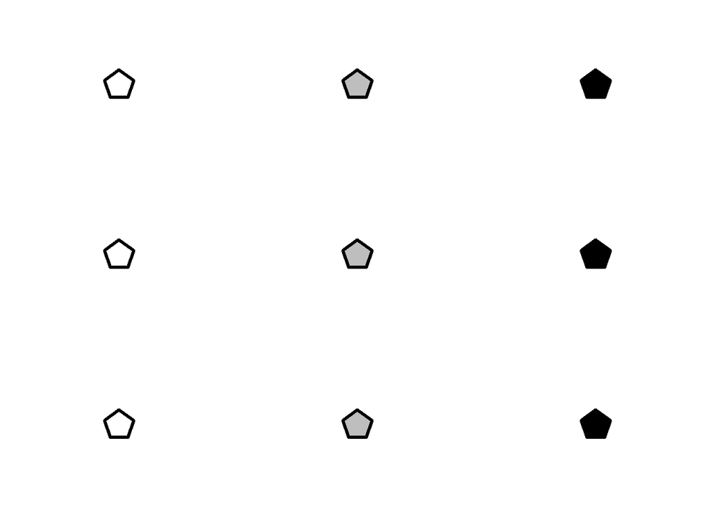

```r
#Horizontal
M<-apply(Raven(st1=pentagon(),hrule=c("fill"),vrule=c("identity")))
draw(M)
```

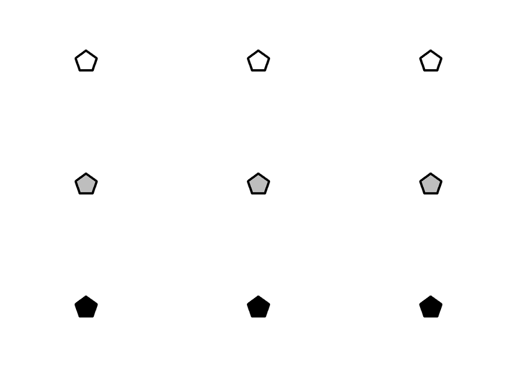

```r
#Vertical
M<-apply(Raven(st1=pentagon(),hrule=c("identity"),vrule=c("fill")))
draw(M)
```

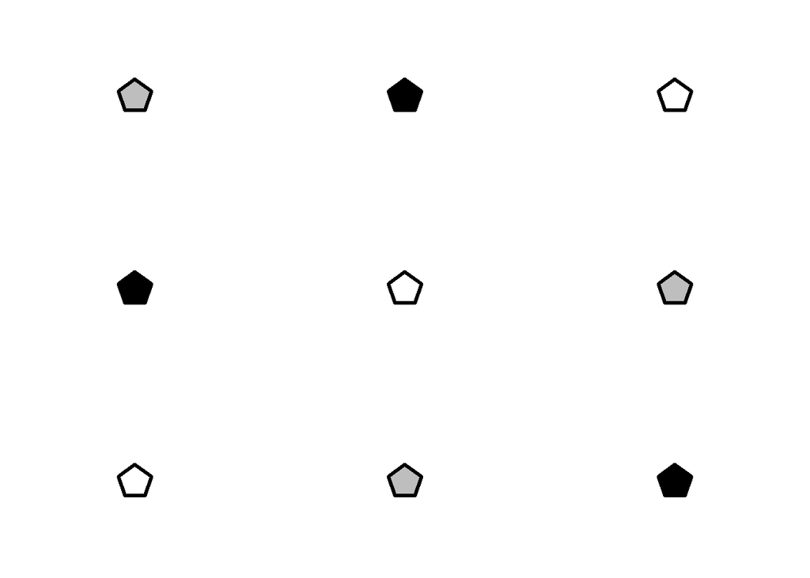

```r
# Top Left Low Right
M<-apply(Raven(st1=pentagon(),hrule=c("fill"),vrule=c("fill")))
draw(M)
```

### 6.4.4 Riempimento con altre forme

## 6.5 Logica

Le regole logiche vengono applicate per riga e per colonna con 3 o più forme. Presento gli elementi basi per applicare la logica in termini insiemistici.

```r
logic.field<-function(obj,n,rule,seed,...) {
    if(length(obj$shape)<3)
    {
      stop("You must have three forms to apply a logical AND !")
    }

  ##gestione di più immagini
  domain<-1:length(obj$shape)

  obj$visible[domain]<-1
  set.seed(seed)
  fixed<-sample(domain,round(length(obj$shape)/5))
  domain<-setdiff(domain,fixed)
  half<-length(domain)%/%2
  index<-list()
  index[[1]]<-sample(domain,half)
  index[[2]]<-sample(setdiff(domain,index[[1]]),half)

  if(rule=="AND"){
    index[[3]]<-union(index[[1]],index[[2]])
    obj$visible[index[[n]]]<-0
  }else if(rule=="OR"){
    if(n<3){
      obj$visible[index[[n]]]<-0
    }
  }else if(rule=="XOR"){
    index[[3]]<-union(setdiff(domain,union(index[[1]],index[[2]])),fixed)
    obj$visible[index[[n]]]<-0
  }
  return(obj)
}
```

- `domain`è l’insieme delle forme $D$
- `fixed` è l’intersezione tra la prima e la seconda cella $C_1 \cap C_2$
- `index[[1]]` è l’insieme delle forme nella prima cella meno l’intersezione $C_1 / \{ C_1 \cap C_2\}$
- `index[[2]]` è l’insieme delle forme nella seconda cella meno l’intersezione $C_2 / \{ C_1 \cap C_2\}$

Questi insiemi vengono mantenuti costanti per riga (o per colonna) tramite dei differenti semi.

### 6.5.1 AND

### 6.5.2 OR

### 6.5.3 Xor